# Importing the Libraries

```python
## Pandas and Numpy

import pandas as pd
import numpy as np

## Plotting libraries

import matplotlib.pyplot as plt
import seaborn as sns

## Ignore Warnings

import warnings
warnings.filterwarnings('ignore')

## Stats Libraries

from scipy.stats import chisquare

import statsmodels.api as sm
from statsmodels.formula.api import ols

## Machine Learning Libraries

from sklearn.model_selection import train_test_split
from sklearn.tree import DecisionTreeClassifier
from sklearn.ensemble import BaggingClassifier
from sklearn.ensemble import RandomForestClassifier
from sklearn.ensemble import AdaBoostClassifier
from sklearn.ensemble import GradientBoostingClassifier
from sklearn.metrics import accuracy_score, classification_report, confusion_matrix
from xgboost import XGBClassifier ## XGBoost Classifier had to installed seperately
```

# Importing and Checking the Data

```python
df1 = pd.read_csv('TelcomCustomer-Churn_1.csv')
df2 = pd.read_csv('TelcomCustomer-Churn_2.csv')
```

```python
## Cheking the shape and size of each dataset:

print('Shape of first dataset:', df1.shape)
print('Shape of second dataset:', df2.shape)
```

```
Shape of first dataset: (7043, 10)
Shape of second dataset: (7043, 12)
```

```python
## Checking the column names and top 5 rows of each of the Datasets

df1.head()
```

|  | customerID | gender | SeniorCitizen | Partner | Dependents | tenure | PhoneService | MultipleLines | InternetService | OnlineSecurity |
| --- | --- | --- | --- | --- | --- | --- | --- | --- | --- | --- |
| 0 | 7590-VHVEG | Female | 0 | Yes | No | 1 | No | No phone service | DSL | No |
| 1 | 5575-GNVDE | Male | 0 | No | No | 34 | Yes | No | DSL | Yes |
| 2 | 3668-QPYBK | Male | 0 | No | No | 2 | Yes | No | DSL | Yes |
| 3 | 7795-CFOCW | Male | 0 | No | No | 45 | No | No phone service | DSL | Yes |
| 4 | 9237-HQITU | Female | 0 | No | No | 2 | Yes | No | Fiber optic | No |

```python
## Checking the column names and top 5 rows of each of the Datasets

df2.head()
```

|  | customerID | OnlineBackup | DeviceProtection | TechSupport | StreamingTV | StreamingMovies | Contract | PaperlessBilling | PaymentMethod | MonthlyCharges | TotalCharges | Churn |
| --- | --- | --- | --- | --- | --- | --- | --- | --- | --- | --- | --- | --- |
| 0 | 7590-VHVEG | Yes | No | No | No | No | Month-to-month | Yes | Electronic check | 29.85 | 29.85 | No |
| 1 | 5575-GNVDE | No | Yes | No | No | No | One year | No | Mailed check | 56.95 | 1889.5 | No |
| 2 | 3668-QPYBK | Yes | No | No | No | No | Month-to-month | Yes | Mailed check | 53.85 | 108.15 | Yes |
| 3 | 7795-CFOCW | No | Yes | Yes | No | No | One year | No | Bank transfer (automatic) | 42.30 | 1840.75 | No |
| 4 | 9237-HQITU | No | No | No | No | No | Month-to-month | Yes | Electronic check | 70.70 | 151.65 | Yes |

```python
## Merging the two dataframes into one dataframe

df = df1.merge(df2)
```

```python
## Cheking the shape and size of the new dataframe

print('Shape of new dataframe:',df.shape)
```

```
Shape of new dataframe: (7043, 21)
```

# Data Cleansing

```python
## Checking for null values and datatypes

df.info()
```

```
<class 'pandas.core.frame.DataFrame'>
Int64Index: 7043 entries, 0 to 7042
Data columns (total 21 columns):
 #   Column            Non-Null Count  Dtype
---  ------            --------------  -----
 0   customerID        7043 non-null   object
 1   gender            7043 non-null   object
 2   SeniorCitizen     7043 non-null   int64
 3   Partner           7043 non-null   object
 4   Dependents        7043 non-null   object
 5   tenure            7043 non-null   int64
 6   PhoneService      7043 non-null   object
 7   MultipleLines     7043 non-null   object
 8   InternetService   7043 non-null   object
 9   OnlineSecurity    7043 non-null   object
 10  OnlineBackup      7043 non-null   object
 11  DeviceProtection  7043 non-null   object
 12  TechSupport       7043 non-null   object
 13  StreamingTV       7043 non-null   object
 14  StreamingMovies   7043 non-null   object
 15  Contract          7043 non-null   object
 16  PaperlessBilling  7043 non-null   object
 17  PaymentMethod     7043 non-null   object
 18  MonthlyCharges    7043 non-null   float64
 19  TotalCharges      7043 non-null   object
 20  Churn             7043 non-null   object
dtypes: float64(1), int64(2), object(18)
memory usage: 1.2+ MB
```

```python
## Checking for summary of the numeric variables

df.describe()
```

|  | SeniorCitizen | tenure | MonthlyCharges |
| --- | --- | --- | --- |
| count | 7043.000000 | 7043.000000 | 7043.000000 |
| mean | 0.162147 | 32.371149 | 64.761692 |
| std | 0.368612 | 24.559481 | 30.090047 |
| min | 0.000000 | 0.000000 | 18.250000 |
| 25% | 0.000000 | 9.000000 | 35.500000 |
| 50% | 0.000000 | 29.000000 | 70.350000 |
| 75% | 0.000000 | 55.000000 | 89.850000 |
| max | 1.000000 | 72.000000 | 118.750000 |

#### There are no null values.

#### Senior Citizen is an integer but we will use it as a categorical variable

```python
df.SeniorCitizen = df.SeniorCitizen.astype(str)
```

```python
df = df.replace({"SeniorCitizen":     {"0": 'No', "1": "Yes"}})
```

```python
df.info()
```

```
<class 'pandas.core.frame.DataFrame'>
Int64Index: 7043 entries, 0 to 7042
Data columns (total 21 columns):
 #   Column            Non-Null Count  Dtype
---  ------            --------------  -----
 0   customerID        7043 non-null   object
 1   gender            7043 non-null   object
 2   SeniorCitizen     7043 non-null   object
 3   Partner           7043 non-null   object
 4   Dependents        7043 non-null   object
 5   tenure            7043 non-null   int64
 6   PhoneService      7043 non-null   object
 7   MultipleLines     7043 non-null   object
 8   InternetService   7043 non-null   object
 9   OnlineSecurity    7043 non-null   object
 10  OnlineBackup      7043 non-null   object
 11  DeviceProtection  7043 non-null   object
 12  TechSupport       7043 non-null   object
 13  StreamingTV       7043 non-null   object
 14  StreamingMovies   7043 non-null   object
 15  Contract          7043 non-null   object
 16  PaperlessBilling  7043 non-null   object
 17  PaymentMethod     7043 non-null   object
 18  MonthlyCharges    7043 non-null   float64
 19  TotalCharges      7043 non-null   object
 20  Churn             7043 non-null   object
dtypes: float64(1), int64(1), object(19)
memory usage: 1.2+ MB
```

### Automating Data Cleansing

1. dropping any NA values
2. dropping columns not usable for analysis
3. finding which columns may have missing values
4. removing missing values
5. converting categorical variables to continuous where applicable
6. checking the categories and their counts for each variable

```python
print('Dropping all NA values\n')
df.dropna(inplace=True)
for i in df.columns:
    if len(df[i].unique()) ==len(df) and type(df[i][92])==str:
        print(f'Dropping the column {i}, as it cannot add value in analysis because of all unique values\n')
        df = df.drop(i, axis = 1)

    else:
        for j in df[i].unique():
            if j==' ' or j=='?':
                print (i,'has missing values','\n')
                print (f'Removing missing values in {i}','\n')
                df = df[df[i]!= j]
        try:
            float(df[i][115])
            float_number = True
            if type(df[i][110])!=str:
                print(i, 'is a continuous variable\n')
            else:
                print(i, 'is a continuous variable but marked as categorical\n')
                print(f'Converting {i} to a continuous variable type\n')
                df[i] = df[i].astype(float)
        except:
            print(i,'is not a continuous variable\n')
        print(i,'\n')
        print(df[i].value_counts())
        print('\n')
```

```
Dropping all NA values

Dropping the column customerID, as it cannot add value in analysis because of all unique values

gender is not a continuous variable

gender

Male      3555
Female    3488
Name: gender, dtype: int64


SeniorCitizen is not a continuous variable

SeniorCitizen

No     5901
Yes    1142
Name: SeniorCitizen, dtype: int64


Partner is not a continuous variable

Partner

No     3641
Yes    3402
Name: Partner, dtype: int64


Dependents is not a continuous variable

Dependents

No     4933
Yes    2110
Name: Dependents, dtype: int64


```

[output cut: 171 more lines]

```
6424.70     1
1474.35     1
6668.35     1
6096.90     1
5867.00     1
Name: TotalCharges, Length: 6530, dtype: int64


Churn is not a continuous variable

Churn

No     5163
Yes    1869
Name: Churn, dtype: int64
```

### All categorical variables will be converted to Numeric(int/float) for modelling purpose at a later stage.

### In the current stage they are required to be in Categorical form for better/easier analysis

```python
df.info()
```

```
<class 'pandas.core.frame.DataFrame'>
Int64Index: 7032 entries, 0 to 7042
Data columns (total 20 columns):
 #   Column            Non-Null Count  Dtype
---  ------            --------------  -----
 0   gender            7032 non-null   object
 1   SeniorCitizen     7032 non-null   object
 2   Partner           7032 non-null   object
 3   Dependents        7032 non-null   object
 4   tenure            7032 non-null   int64
 5   PhoneService      7032 non-null   object
 6   MultipleLines     7032 non-null   object
 7   InternetService   7032 non-null   object
 8   OnlineSecurity    7032 non-null   object
 9   OnlineBackup      7032 non-null   object
 10  DeviceProtection  7032 non-null   object
 11  TechSupport       7032 non-null   object
 12  StreamingTV       7032 non-null   object
 13  StreamingMovies   7032 non-null   object
 14  Contract          7032 non-null   object
 15  PaperlessBilling  7032 non-null   object
 16  PaymentMethod     7032 non-null   object
 17  MonthlyCharges    7032 non-null   float64
 18  TotalCharges      7032 non-null   float64
 19  Churn             7032 non-null   object
dtypes: float64(2), int64(1), object(17)
memory usage: 1.4+ MB
```

# Data Analysis and Visualization

#### To check the effect of the different variables we will check the distribution of these variables with respect to whether the customer churns or not

##### Gender

```
Male      3549
Female    3483
Name: gender, dtype: int64
```

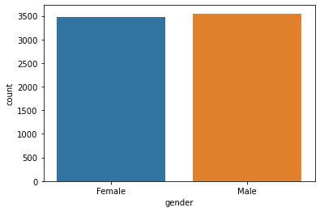

```python
## Checking the distribution of Gender

print(df.gender.value_counts())
sns.countplot(x = df.gender);
```

#### We have almost equal number of male and female subscribers

```
Churn for Males
 No     2619
Yes     930
Name: Churn, dtype: int64

Churn for Females
 No     2544
Yes     939
Name: Churn, dtype: int64
```

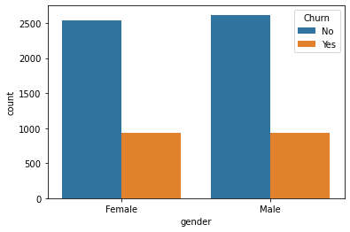

```python
## Checking the distribution of Female and Male subscribers with respect to whether they churned or not


print("Churn for Males",'\n', df[df.gender=='Male'].Churn.value_counts(),'\n')
print("Churn for Females",'\n',df[df.gender=='Female'].Churn.value_counts())
sns.countplot(x = df.gender, hue = df.Churn);
```

```python
## Comparing Total Churn to Churn amongst Males and Churn amongst Females

print('Percentage Churn in Total Subscribers is',round(100*df.Churn.value_counts(1)[1],2),'percent')
print('Percentage Churn in Males is',round(100* df[df.gender =='Male'].Churn.value_counts(1)[1],2),'percent')
print('Percentage Churn in Females is',round(100* df[df.gender =='Female'].Churn.value_counts(1)[1],2),'percent')
```

```
Percentage Churn in Total Subscribers is 26.58 percent
Percentage Churn in Males is 26.2 percent
Percentage Churn in Females is 26.96 percent
```

```python
## Testing the hypothesis that Churn is independent of gender with chi-square test
## Null Hypothesis is that Churn is similar for both males and females therefore Churn is independent of gender

chisquare([26.20,26.96], f_exp = [26.58,26.58])
```

```
Power_divergenceResult(statistic=0.010865312264860844, pvalue=0.9169814240314739)
```

##### Since p value > 0.05 therefore we fail to reject the Null Hypothesis

##### Therefore we conclude on the basis of the plots, percentage of Churn for each gender and Chi-Square Test that Churn is independent of gender

##### Senior Citizen

```
No     5890
Yes    1142
Name: SeniorCitizen, dtype: int64
```

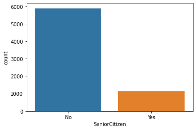

```python
## Checking the distribution of Senior Citizen

print(df.SeniorCitizen.value_counts())
sns.countplot(x = df.SeniorCitizen);
```

```
Churn for Senior Citizens
 No     666
Yes    476
Name: Churn, dtype: int64

Churn for non-Senior Citizens
 No     4497
Yes    1393
Name: Churn, dtype: int64
```

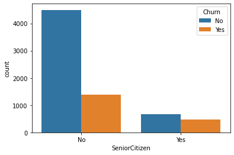

```python
## Checking the distribution of Senior Citizen subscribers with respect to whether they churned or not

print("Churn for Senior Citizens",'\n', df[df.SeniorCitizen=='Yes'].Churn.value_counts(),'\n')
print("Churn for non-Senior Citizens",'\n',df[df.SeniorCitizen=='No'].Churn.value_counts())
sns.countplot(x = df.SeniorCitizen, hue = df.Churn);
```

```python
## Comparing Total Churn to Churn amongst Senior Citizens and Churn amongst others

print('Percentage Churn in Total Subscribers is',round(100*df.Churn.value_counts(1)[1],2),'percent')
print('Percentage Churn in Senior Citizens is',round(100* df[df.SeniorCitizen=='Yes'].Churn.value_counts(1)[1],2),'percent')
print('Percentage Churn in non-Senior Citizens is',round(100* df[df.SeniorCitizen=='No'].Churn.value_counts(1)[1],2),'percent')
```

```
Percentage Churn in Total Subscribers is 26.58 percent
Percentage Churn in Senior Citizens is 41.68 percent
Percentage Churn in non-Senior Citizens is 23.65 percent
```

```python
## Testing the hypothesis that Churn is independent of whether a subscriber is a senior citizen or not with chi-square test
## Null Hypothesis is that Churn is independent of whether a subscriber is a senior citizen or not

chisquare([41.68,23.65], f_exp = [26.58,26.58])
```

```
Power_divergenceResult(statistic=8.901237772761476, pvalue=0.002849774164006351)
```

##### Since p value < 0.05 therefore we reject the null hypothesis that Churn is independent of whether a subscriber is a senior citizen or not. We clearly see that if a subscriber is a senior citizen he/she is more likely to churn than others.

##### Partner

```
No     3639
Yes    3393
Name: Partner, dtype: int64
```

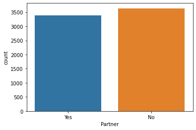

```python
## Checking the distribution of whether a subscriber has a partner or not
print(df.Partner.value_counts())
sns.countplot(x = df.Partner);
```

```
Churn for subscribers with partners
 No     2724
Yes     669
Name: Churn, dtype: int64

Churn for subscribers without partners
 No     2439
Yes    1200
Name: Churn, dtype: int64
```

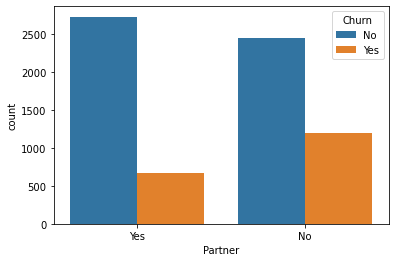

```python
## Checking the distribution of subscribers with partners and without partners with respect to whether they churned or not


print("Churn for subscribers with partners",'\n', df[df.Partner=='Yes'].Churn.value_counts(),'\n')
print("Churn for subscribers without partners",'\n',df[df.Partner=='No'].Churn.value_counts())
sns.countplot(x = df.Partner, hue = df.Churn);
```

```python
## Comparing Total Churn to Churn amongst subscribers with partners and those without partners

print('Percentage Churn in Total Subscribers is',round(100*df.Churn.value_counts(1)[1],2),'percent')
print('Percentage Churn in subscribers with partners is',round(100* df[df.Partner == 'Yes'].Churn.value_counts(1)[1],2),'percent')
print('Percentage Churn in subscribers without partners is',round(100* df[df.Partner == 'No'].Churn.value_counts(1)[1],2),'percent')
```

```
Percentage Churn in Total Subscribers is 26.58 percent
Percentage Churn in subscribers with partners is 19.72 percent
Percentage Churn in subscribers without partners is 32.98 percent
```

```python
## Testing the hypothesis that Churn is independent of whether a subscriber has a partner or not with chi-square test
## Null Hypothesis is that Churn is independent of whether a subscriber has a partner or not

chisquare([19.72,32.98], f_exp = [26.58,26.58])
```

```
Power_divergenceResult(statistic=3.311497366440932, pvalue=0.06879677943580055)
```

##### Since p value > 0.05 therefore we fail to reject the null hypothesis that Churn is independent of whether a subscriber has a partner or not.

##### However, we need to notice that the p value is very close to 0.05.

##### Dependents

```
No     4933
Yes    2099
Name: Dependents, dtype: int64
```

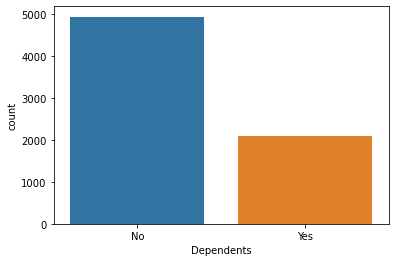

```python
## Checking the distribution of whether a subscriber has dependents or not
print(df.Dependents.value_counts())
sns.countplot(x = df.Dependents);
```

```
Churn for subscribers with dependents
 No     1773
Yes     326
Name: Churn, dtype: int64

Churn for subscribers without dependents
 No     3390
Yes    1543
Name: Churn, dtype: int64
```

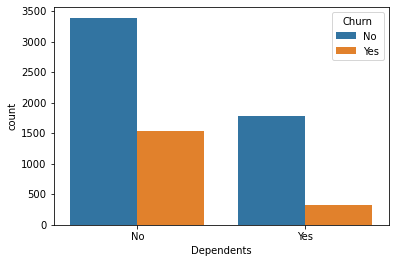

```python
## Checking the distribution of subscribers with dependaents and without dependents with respect to whether they churned or not


print("Churn for subscribers with dependents",'\n', df[df.Dependents=='Yes'].Churn.value_counts(),'\n')
print("Churn for subscribers without dependents",'\n',df[df.Dependents=='No'].Churn.value_counts())
sns.countplot(x = df.Dependents, hue = df.Churn);
```

```python
## Comparing Total Churn to Churn amongst subscribers with dependents and those without dependents

print('Percentage Churn in Total Subscribers is',round(100*df.Churn.value_counts(1)[1],2),'percent')
print('Percentage Churn in subscribers with dependents is',round(100* df[df.Dependents == 'Yes'].Churn.value_counts(1)[1],2),'percent')
print('Percentage Churn in subscribers without dependents is',round(100* df[df.Dependents == 'No'].Churn.value_counts(1)[1],2),'percent')
```

```
Percentage Churn in Total Subscribers is 26.58 percent
Percentage Churn in subscribers with dependents is 15.53 percent
Percentage Churn in subscribers without dependents is 31.28 percent
```

```python
## Testing the hypothesis that Churn is independent of whether a subscriber has dependents or not with chi-square test
## Null Hypothesis is that Churn is independent of whether a subscriber has dependents or not

chisquare([15.53,31.28], f_exp = [26.58,26.58])
```

```
Power_divergenceResult(statistic=5.42484951091046, pvalue=0.019852146249538804)
```

##### Since p value < 0.05 therefore we reject the null hypothesis that Churn is independent of whether a subscriber has dependents or not. We clearly see that if a subscriber does not have dependents he/she is more likely to churn than others.

##### Tenure

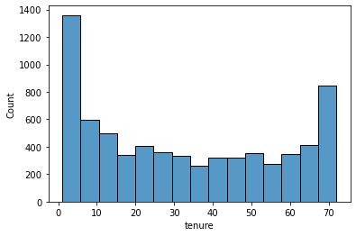

```python
## Checking the distribution of Tenure

sns.histplot(x = df.tenure);
```

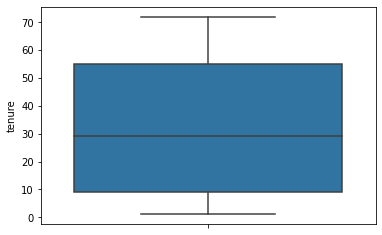

```python
## Boxplot

sns.boxplot(y = df.tenure);
```

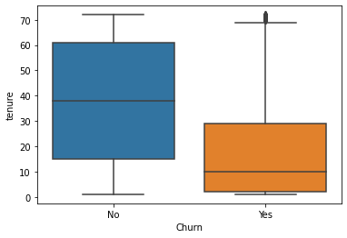

```python
## Checking distribution of tenure with respect to Churn

sns.boxplot(y = df.tenure, x = df.Churn);
```

```python
## We see that people who churned have a lower average tenure. We can confirm this with an ANOVA test
## NULL Hypothesis is that the average tenure for people who churn and those----
## ----who do not is the same (difference is not statistically significant)

mod = ols('tenure ~ Churn', data = df).fit()
aov_table = sm.stats.anova_lm(mod, typ = 2)
print(aov_table)
```

```
                sum_sq      df            F         PR(>F)
Churn     5.309822e+05     1.0  1007.509431  9.437650e-207
Residual  3.704983e+06  7030.0          NaN            NaN
```

##### Since p value <0.05 we reject the null hypothesis. We see that people who have churned have lower tenure on average.

##### Phone Service

```
Yes    6352
No      680
Name: PhoneService, dtype: int64
```

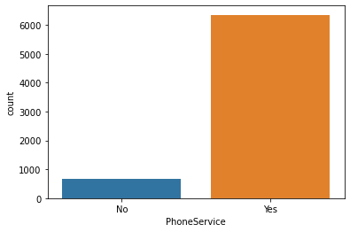

```python
## Checking the distribution of whether a subscriber has Phone service or not

print(df.PhoneService.value_counts())
sns.countplot(x = df.PhoneService);
```

```
Churn for subscribers with phone service
 No     4653
Yes    1699
Name: Churn, dtype: int64

Churn for subscribers without phone service
 No     510
Yes    170
Name: Churn, dtype: int64
```

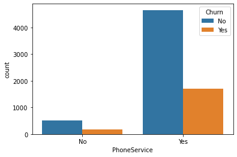

```python
## Checking the distribution of subscribers with phone service and without phone service with respect to whether they churned or not


print("Churn for subscribers with phone service",'\n', df[df.PhoneService=='Yes'].Churn.value_counts(),'\n')
print("Churn for subscribers without phone service",'\n',df[df.PhoneService=='No'].Churn.value_counts())
sns.countplot(x = df.PhoneService, hue = df.Churn);
```

```python
## Comparing Total Churn to Churn amongst subscribers with phone service and those without phone service

print('Percentage Churn in Total Subscribers is',round(100*df.Churn.value_counts(1)[1],2),'percent')
print('Percentage Churn in subscribers with phone service is',round(100* df[df.PhoneService == 'Yes'].Churn.value_counts(1)[1],2),'percent')
print('Percentage Churn in subscribers without phone service is',round(100* df[df.PhoneService == 'No'].Churn.value_counts(1)[1],2),'percent')
```

```
Percentage Churn in Total Subscribers is 26.58 percent
Percentage Churn in subscribers with phone service is 26.75 percent
Percentage Churn in subscribers without phone service is 25.0 percent
```

```python
## Testing the hypothesis that Churn is independent of whether a subscriber has phone service or not with chi-square test
## Null Hypothesis is that Churn is independent of whether a subscriber has phone service or not

chisquare([26.75,25], f_exp = [26.58,26.58])
```

```
Power_divergenceResult(statistic=0.09500752445447688, pvalue=0.7579051150678662)
```

##### Since p value > 0.05 therefore we fail to reject the Null Hypothesis

##### Therefore we conclude on the basis of the plots, percentage of Churn for subscribers with and without phone service and Chi-Square Test that Churn is independent of whether a subscriber has phone service or not

##### Multiple Lines

```
No                  3385
Yes                 2967
No phone service     680
Name: MultipleLines, dtype: int64
```

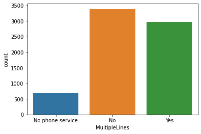

```python
## Checking the distribution of whether a subscriber has Multiple Lines or not

print(df.MultipleLines.value_counts())
sns.countplot(x = df.MultipleLines);
```

```
Churn for subscribers with multiple lines
 No     2117
Yes     850
Name: Churn, dtype: int64

Churn for subscribers without multiple lines
 No     2536
Yes     849
Name: Churn, dtype: int64

Churn for subscribers without phone service
 No     510
Yes    170
Name: Churn, dtype: int64
```

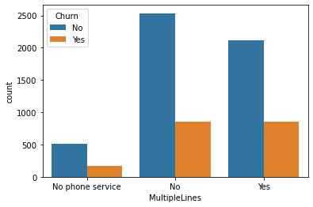

```python
## Checking the distribution of subscribers with multiple lines and without multiple lines with respect to whether they churned or not


print("Churn for subscribers with multiple lines",'\n', df[df.MultipleLines=='Yes'].Churn.value_counts(),'\n')
print("Churn for subscribers without multiple lines",'\n',df[df.MultipleLines=='No'].Churn.value_counts(),'\n')
print("Churn for subscribers without phone service",'\n',df[df.MultipleLines=='No phone service'].Churn.value_counts())
sns.countplot(x = df.MultipleLines, hue = df.Churn);
```

```python
## Comparing Total Churn to Churn amongst subscribers with multiple lines and those without multiple lines

print('Percentage Churn in Subscribers who have phone service is',round(100*df[df.MultipleLines!='No phone service'].Churn.value_counts(1)[1],2),'percent')
print('Percentage Churn in subscribers with multiple lines is',round(100* df[df.MultipleLines == 'Yes'].Churn.value_counts(1)[1],2),'percent')
print('Percentage Churn in subscribers without multiple lines is',round(100* df[df.MultipleLines == 'No'].Churn.value_counts(1)[1],2),'percent')
```

```
Percentage Churn in Subscribers who have phone service is 26.75 percent
Percentage Churn in subscribers with multiple lines is 28.65 percent
Percentage Churn in subscribers without multiple lines is 25.08 percent
```

```python
## Testing the hypothesis that Churn is independent of whether a subscriber has multiple lines or not with chi-square test
## Null Hypothesis is that Churn is independent of whether a subscriber has multiple lines or not

chisquare([28.65,25.08], f_exp = [26.75,26.75])
```

```
Power_divergenceResult(statistic=0.23921121495327102, pvalue=0.6247763981566744)
```

##### Since p value > 0.05 therefore we fail to reject the Null Hypothesis

##### Therefore we conclude on the basis of the plots, percentage of Churn for subscribers with and without multiple lines and Chi-Square Test that Churn is independent of whether a subscriber has multiple lines or not.

##### Internet Service

```
Fiber optic    3096
DSL            2416
No             1520
Name: InternetService, dtype: int64
```

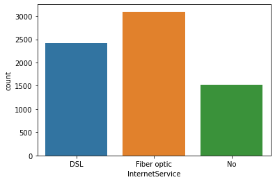

```python
## Checking the distribution of what internet service subscriber has

print(df.InternetService.value_counts())
sns.countplot(x = df.InternetService);
```

```
Churn for subscribers of DSL
 No     1957
Yes     459
Name: Churn, dtype: int64

Churn for subscribers of Fiber optic
 No     1799
Yes    1297
Name: Churn, dtype: int64

Churn for subscribers without internet service
 No     1407
Yes     113
Name: Churn, dtype: int64
```

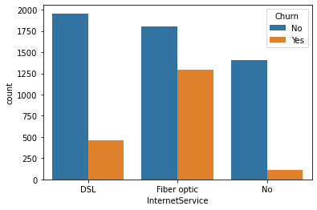

```python
## Checking the distribution of the internet service with respect to whether they churned or not


print("Churn for subscribers of DSL",'\n', df[df.InternetService=='DSL'].Churn.value_counts(),'\n')
print("Churn for subscribers of Fiber optic",'\n',df[df.InternetService=='Fiber optic'].Churn.value_counts(),'\n')
print("Churn for subscribers without internet service",'\n',df[df.InternetService=='No'].Churn.value_counts())
sns.countplot(x = df.InternetService, hue = df.Churn);
```

```python
## Comparing Total Churn to Churn amongst subscribers with different types of internet service and no internet service

print('Percentage Churn in Total Subscribers is',round(100*df.Churn.value_counts(1)[1],2),'percent')
print('Percentage Churn in subscribers with DSL is',round(100* df[df.InternetService == 'DSL'].Churn.value_counts(1)[1],2),'percent')
print('Percentage Churn in subscribers with Fiber optic lines is',round(100* df[df.InternetService == 'Fiber optic'].Churn.value_counts(1)[1],2),'percent')
print('Percentage Churn in subscribers without internet service is',round(100* df[df.InternetService == 'No'].Churn.value_counts(1)[1],2),'percent')
```

```
Percentage Churn in Total Subscribers is 26.58 percent
Percentage Churn in subscribers with DSL is 19.0 percent
Percentage Churn in subscribers with Fiber optic lines is 41.89 percent
Percentage Churn in subscribers without internet service is 7.43 percent
```

```python
## Testing the hypothesis that Churn is independent of type of internet service or whether a subscriber has internet service or not with chi-square test
## Null Hypothesis is that Churn is independent of type of internet service and whether a subscriber has internet service or not

chisquare([19,41.89,7.43], f_exp = [26.58,26.58,26.58])
```

```
Power_divergenceResult(statistic=24.777088036117384, pvalue=4.166042481196892e-06)
```

##### Since p value <0.05 we reject the null hypothesis. We see that people who have churned tended to have fiber optic.

### It is important to note that going forward for variables that have a category No internet service we will need to do the Hypothesis test after removing the subscribers without internet service. Since we have already observed the effect of not having internet service and if we continue to have that in the analysis it may skew results

##### Online Security

```
No                     3497
Yes                    2015
No internet service    1520
Name: OnlineSecurity, dtype: int64
```

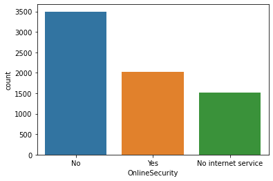

```python
## Checking the distribution of whether subscribers had online security or not

print(df.OnlineSecurity.value_counts())
sns.countplot(x = df.OnlineSecurity);
```

```
Churn for subscribers with online security
 No     1720
Yes     295
Name: Churn, dtype: int64

Churn for subscribers with no online security
 No     2036
Yes    1461
Name: Churn, dtype: int64

Churn for subscribers without internet service
 No     1407
Yes     113
Name: Churn, dtype: int64
```

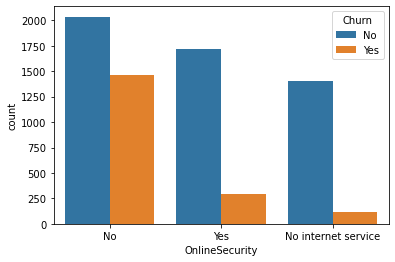

```python
## Checking the distribution of online security with respect to churn

print("Churn for subscribers with online security",'\n', df[df.OnlineSecurity=='Yes'].Churn.value_counts(),'\n')
print("Churn for subscribers with no online security",'\n',df[df.OnlineSecurity=='No'].Churn.value_counts(),'\n')
print("Churn for subscribers without internet service",'\n',df[df.OnlineSecurity=='No internet service'].Churn.value_counts())
sns.countplot(x = df.OnlineSecurity, hue = df.Churn);
```

```python
## Comparing Total Churn to Churn amongst subscribers with online security and without online security

print('Percentage Churn in Subscribers with internet service is',round(100*df[df.OnlineSecurity!='No internet service'].Churn.value_counts(1)[1],2),'percent')
print('Percentage Churn in subscribers with online security is',round(100* df[df.OnlineSecurity == 'Yes'].Churn.value_counts(1)[1],2),'percent')
print('Percentage Churn in subscribers without online security is',round(100* df[df.OnlineSecurity == 'No'].Churn.value_counts(1)[1],2),'percent')
```

```
Percentage Churn in Subscribers with internet service is 31.86 percent
Percentage Churn in subscribers with online security is 14.64 percent
Percentage Churn in subscribers without online security is 41.78 percent
```

```python
## Testing the hypothesis that Churn is independent of online security with chi-square test
## Null Hypothesis is that Churn is independent of online security

chisquare([14.64,41.78], f_exp = [31.86,31.86])
```

```
Power_divergenceResult(statistic=12.39594475831764, pvalue=0.0004302672451835325)
```

##### Since p value <0.05 we reject the null hypothesis. We see that people who have no internet security are more likely to churn

##### Online Backup

```
No                     3087
Yes                    2425
No internet service    1520
Name: OnlineBackup, dtype: int64
```

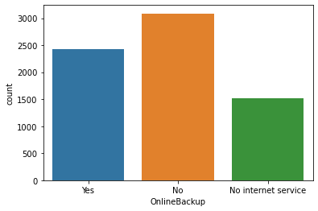

```python
## Checking the distribution of whether subscribers had online backup or not

print(df.OnlineBackup.value_counts())
sns.countplot(x = df.OnlineBackup);
```

```
Churn for subscribers with online backup
 No     1902
Yes     523
Name: Churn, dtype: int64

Churn for subscribers with no online backup
 No     1854
Yes    1233
Name: Churn, dtype: int64

Churn for subscribers without internet service
 No     1407
Yes     113
Name: Churn, dtype: int64
```

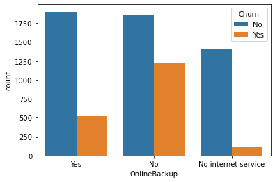

```python
## Checking the distribution of online backup with respect to churn

print("Churn for subscribers with online backup",'\n', df[df.OnlineBackup=='Yes'].Churn.value_counts(),'\n')
print("Churn for subscribers with no online backup",'\n',df[df.OnlineBackup=='No'].Churn.value_counts(),'\n')
print("Churn for subscribers without internet service",'\n',df[df.OnlineBackup=='No internet service'].Churn.value_counts())
sns.countplot(x = df.OnlineBackup, hue = df.Churn);
```

```python
## Comparing Total Churn to Churn amongst subscribers with online backup, without online backup

print('Percentage Churn in Subscribers with internet service is',round(100*df[df.OnlineBackup != 'No internet service' ].Churn.value_counts(1)[1],2),'percent')
print('Percentage Churn in subscribers with online backup is',round(100* df[df.OnlineBackup == 'Yes'].Churn.value_counts(1)[1],2),'percent')
print('Percentage Churn in subscribers without online backup is',round(100* df[df.OnlineBackup == 'No'].Churn.value_counts(1)[1],2),'percent')
```

```
Percentage Churn in Subscribers with internet service is 31.86 percent
Percentage Churn in subscribers with online backup is 21.57 percent
Percentage Churn in subscribers without online backup is 39.94 percent
```

```python
## Testing the hypothesis that Churn is independent of online backup with chi-square test
## Null Hypothesis is that Churn is independent of online backup

chisquare([21.57,39.94], f_exp = [31.86,31.86])
```

```
Power_divergenceResult(statistic=5.372583176396734, pvalue=0.020455662132985056)
```

##### Since p value <0.05 we reject the null hypothesis. We see that people who do not have online backup are more likely to churn

##### Device Protection

```
No                     3094
Yes                    2418
No internet service    1520
Name: DeviceProtection, dtype: int64
```

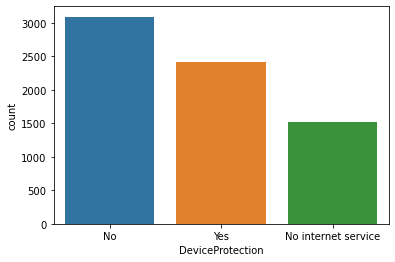

```python
## Checking the distribution of whether subscribers had device protection or not

print(df.DeviceProtection.value_counts())
sns.countplot(x = df.DeviceProtection);
```

```
Churn for subscribers with device protection
 No     1873
Yes     545
Name: Churn, dtype: int64

Churn for subscribers with no device protection
 No     1883
Yes    1211
Name: Churn, dtype: int64

Churn for subscribers without internet service
 No     1407
Yes     113
Name: Churn, dtype: int64
```

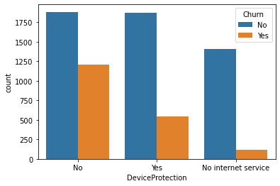

```python
## Checking the distribution of device protection with respect to churn

print("Churn for subscribers with device protection",'\n', df[df.DeviceProtection=='Yes'].Churn.value_counts(),'\n')
print("Churn for subscribers with no device protection",'\n',df[df.DeviceProtection=='No'].Churn.value_counts(),'\n')
print("Churn for subscribers without internet service",'\n',df[df.DeviceProtection=='No internet service'].Churn.value_counts())
sns.countplot(x = df.DeviceProtection, hue = df.Churn);
```

```python
## Comparing Total Churn to Churn amongst subscribers with device protection, without device protection and without internet

print('Percentage Churn in Subscribers with internet service is',round(100*df[df.DeviceProtection!='No internet service'].Churn.value_counts(1)[1],2),'percent')
print('Percentage Churn in subscribers with device protection is',round(100* df[df.DeviceProtection == 'Yes'].Churn.value_counts(1)[1],2),'percent')
print('Percentage Churn in subscribers without device protection is',round(100* df[df.DeviceProtection == 'No'].Churn.value_counts(1)[1],2),'percent')
```

```
Percentage Churn in Subscribers with internet service is 31.86 percent
Percentage Churn in subscribers with device protection is 22.54 percent
Percentage Churn in subscribers without device protection is 39.14 percent
```

```python
## Testing the hypothesis that Churn is independent of device protection with chi-square test
## Null Hypothesis is that Churn is independent of device protection

chisquare([22.54,39.14], f_exp = [31.86,31.86])
```

```
Power_divergenceResult(statistic=4.389855618330195, pvalue=0.03615337466086159)
```

##### Since p value <0.05 we reject the null hypothesis. We see that people who do not have device protection are more likely to churn

##### Tech Support

```
No                     3472
Yes                    2040
No internet service    1520
Name: TechSupport, dtype: int64
```

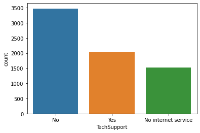

```python
## Checking the distribution of whether subscribers had Tech Support or not

print(df.TechSupport.value_counts())
sns.countplot(x = df.TechSupport);
```

```
Churn for subscribers with Tech Support
 No     1730
Yes     310
Name: Churn, dtype: int64

Churn for subscribers with no Tech Support
 No     2026
Yes    1446
Name: Churn, dtype: int64

Churn for subscribers without internet service
 No     1407
Yes     113
Name: Churn, dtype: int64
```

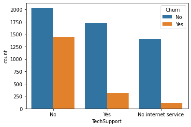

```python
## Checking the distribution of Tech Support with respect to churn

print("Churn for subscribers with Tech Support",'\n', df[df.TechSupport=='Yes'].Churn.value_counts(),'\n')
print("Churn for subscribers with no Tech Support",'\n',df[df.TechSupport=='No'].Churn.value_counts(),'\n')
print("Churn for subscribers without internet service",'\n',df[df.TechSupport=='No internet service'].Churn.value_counts())
sns.countplot(x = df.TechSupport, hue = df.Churn);
```

```python
## Comparing Total Churn to Churn amongst subscribers with tech support, without tech support

print('Percentage Churn in Subscribers with internet service is',round(100*df[df.TechSupport!= 'No internet service'].Churn.value_counts(1)[1],2),'percent')
print('Percentage Churn in subscribers with tech support is',round(100* df[df.TechSupport == 'Yes'].Churn.value_counts(1)[1],2),'percent')
print('Percentage Churn in subscribers without tech support is',round(100* df[df.TechSupport == 'No'].Churn.value_counts(1)[1],2),'percent')
```

```
Percentage Churn in Subscribers with internet service is 31.86 percent
Percentage Churn in subscribers with tech support is 15.2 percent
Percentage Churn in subscribers without tech support is 41.65 percent
```

```python
## Testing the hypothesis that Churn is independent of tech support with chi-square test
## Null Hypothesis is that Churn is independent of tech support

chisquare([15.2,41.65], f_exp = [31.86,31.86])
```

```
Power_divergenceResult(statistic=11.72001569365976, pvalue=0.0006183143316809417)
```

##### Since p value <0.05 we reject the null hypothesis. We see that people who do not have tech support are more likely to churn

##### Streaming TV

```
No                     2809
Yes                    2703
No internet service    1520
Name: StreamingTV, dtype: int64
```

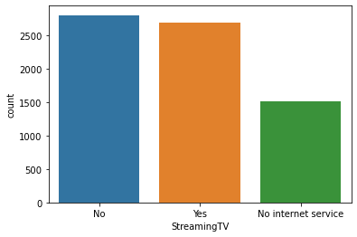

```python
## Checking the distribution of whether subscribers had Streaming TV or not
print(df.StreamingTV.value_counts())
sns.countplot(x = df.StreamingTV);
```

```
Churn for subscribers with Streaming TV
 No     1889
Yes     814
Name: Churn, dtype: int64

Churn for subscribers with no Streaming TV
 No     1867
Yes     942
Name: Churn, dtype: int64

Churn for subscribers without internet service
 No     1407
Yes     113
Name: Churn, dtype: int64
```

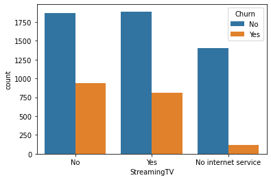

```python
## Checking the distribution of Streaming TV with respect to churn

print("Churn for subscribers with Streaming TV",'\n', df[df.StreamingTV=='Yes'].Churn.value_counts(),'\n')
print("Churn for subscribers with no Streaming TV",'\n',df[df.StreamingTV=='No'].Churn.value_counts(),'\n')
print("Churn for subscribers without internet service",'\n',df[df.StreamingTV=='No internet service'].Churn.value_counts())
sns.countplot(x = df.StreamingTV, hue = df.Churn);
```

```python
## Comparing Total Churn to Churn amongst subscribers with Streaming TV and without Streaming TV

print('Percentage Churn in Subscribers with internet service is',round(100*df[df.StreamingTV != 'No internet service'].Churn.value_counts(1)[1],2),'percent')
print('Percentage Churn in subscribers with Streaming TV is',round(100* df[df.StreamingTV == 'Yes'].Churn.value_counts(1)[1],2),'percent')
print('Percentage Churn in subscribers without Streaming TV is',round(100* df[df.StreamingTV == 'No'].Churn.value_counts(1)[1],2),'percent')
```

```
Percentage Churn in Subscribers with internet service is 31.86 percent
Percentage Churn in subscribers with Streaming TV is 30.11 percent
Percentage Churn in subscribers without Streaming TV is 33.54 percent
```

```python
## Testing the hypothesis that Churn is independent of StreamingTV with chi-square test
## Null Hypothesis is that Churn is independent of StreamingTV

chisquare([30.11,33.54], f_exp = [31.86,31.86])
```

```
Power_divergenceResult(statistic=0.1847112366603892, pvalue=0.6673553541363186)
```

##### Since p value > 0.05 we fail to reject the null hypothesis. We see that the likeliness of churn for people who have streaming tv and people who do not have streaming TV are similar

##### Streaming Movies

```
No                     2781
Yes                    2731
No internet service    1520
Name: StreamingMovies, dtype: int64
```

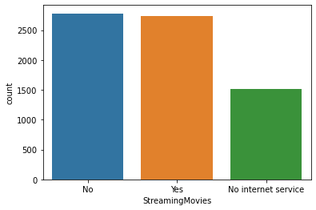

```python
## Checking the distribution of whether subscribers had Streaming Movies or not

print(df.StreamingMovies.value_counts())
sns.countplot(x = df.StreamingMovies);
```

```
Churn for subscribers with Streaming Movies
 No     1913
Yes     818
Name: Churn, dtype: int64

Churn for subscribers with no Streaming Movies
 No     1843
Yes     938
Name: Churn, dtype: int64

Churn for subscribers without internet service
 No     1407
Yes     113
Name: Churn, dtype: int64
```

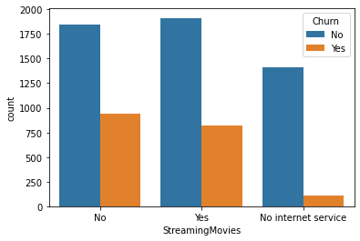

```python
## Checking the distribution of Streaming Movies with respect to churn

print("Churn for subscribers with Streaming Movies",'\n', df[df.StreamingMovies=='Yes'].Churn.value_counts(),'\n')
print("Churn for subscribers with no Streaming Movies",'\n',df[df.StreamingMovies=='No'].Churn.value_counts(),'\n')
print("Churn for subscribers without internet service",'\n',df[df.StreamingMovies=='No internet service'].Churn.value_counts())
sns.countplot(x = df.StreamingMovies, hue = df.Churn);
```

```python
## Comparing Total Churn to Churn amongst subscribers with Streaming Movies and without Streaming TV

print('Percentage Churn in Subscribers with internet service is',round(100*df[df.StreamingMovies != 'No internet service'].Churn.value_counts(1)[1],2),'percent')
print('Percentage Churn in subscribers with Streaming Movies is',round(100* df[df.StreamingMovies == 'Yes'].Churn.value_counts(1)[1],2),'percent')
print('Percentage Churn in subscribers without Streaming Movies is',round(100* df[df.StreamingMovies == 'No'].Churn.value_counts(1)[1],2),'percent')
```

```
Percentage Churn in Subscribers with internet service is 31.86 percent
Percentage Churn in subscribers with Streaming Movies is 29.95 percent
Percentage Churn in subscribers without Streaming Movies is 33.73 percent
```

```python
## Testing the hypothesis that Churn is independent of StreamingMovies with chi-square test
## Null Hypothesis is that Churn is independent of StreamingMovies

chisquare([29.95,33.73], f_exp = [31.86,31.86])
```

```
Power_divergenceResult(statistic=0.22426239799121125, pvalue=0.6358112017722723)
```